# a3_task3_anusha_sridhara.Rmd

Anusha Sridhara

10/23/2021

## Overview

The following data describes the size frequency distribution of red and purple sea urchins at SBC LTER long-term kelp removal experiment sites. The kelp removal experiment was initiated in 2008 at selected reef sites along the maincoast of the Santa Barbara Channel. The following codes wrangle and visualize data for the above mentioned dataset from [Santa Barbara Coastal LTER](https://sbclter.msi.ucsb.edu/data/catalog/package/?package=knb-lter-sbc.26)

** Data Citation **: Reed, D, R. Miller. 2021. SBC LTER: Reef: Long-term experiment: Kelp removal: Urchin size frequency distribution ver 21. Environmental Data Initiative. https://doi.org/10.6073/pasta/fd564dddfe7b77fe9e4bd8417f166057. Accessed 2021-10-23.

## Read in the data

```r
## Reading the data of Urchins ##
urchins <- read_csv(here("data", "urchins.csv"))
```

## For reference, the first 6 lines of the dataset are shown below

```r
##Return the first 6 lines:
head(urchins)
```

```
## # A tibble: 6 x 6
##   DATE     SITE  TREATMENT  SIZE SCIENTIFIC_NAME               COMMON_NAME
##   <chr>    <chr> <chr>     <dbl> <chr>                         <chr>
## 1 10/10/08 NAPL  CONTROL     2.5 Strongylocentrotus purpuratus Purple Urchin
## 2 10/10/08 NAPL  CONTROL     2.5 Strongylocentrotus purpuratus Purple Urchin
## 3 10/10/08 NAPL  CONTROL     2.5 Strongylocentrotus purpuratus Purple Urchin
## 4 10/10/08 NAPL  CONTROL     2.5 Strongylocentrotus purpuratus Purple Urchin
## 5 10/10/08 NAPL  CONTROL     2.5 Strongylocentrotus purpuratus Purple Urchin
## 6 10/10/08 NAPL  CONTROL     2.5 Strongylocentrotus purpuratus Purple Urchin
```

## Converting the names in column to lowercase

```r
##column names converted to lower snake case
urchins_clean <- urchins %>% clean_names()
```

## a) Section 1

### Comparing the distribution of sizes between purple and red urchins with the help of a histogram

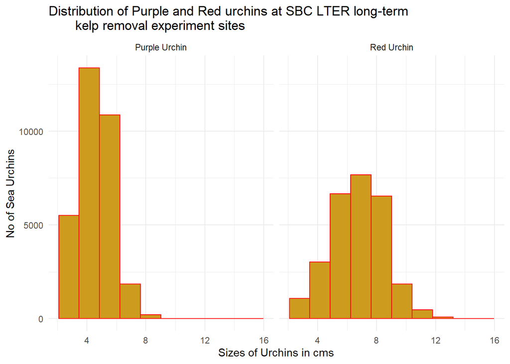

```r
ggplot(data = urchins_clean, aes(x=size))+
  geom_histogram(fill = "goldenrod3",
                 color = "red",
                 bins=10)+
  theme_minimal()+
  facet_wrap(~common_name)+
  labs(x= "Sizes of Urchins in cms",
       y = "No of Sea Urchins",
       title = "Distribution of Purple and Red urchins at SBC LTER long-term
       kelp removal experiment sites")
```

#Fig 1: Sizes of Purple and Red Sea Urchins. The graph above discusses the distribution of purple and red sea urchins found at SBC LTER long-term kelp removal experiment sites

### ii. Descriptive Statistics Table

#### Table 1: Statistical summary of Sea Urchins :Table below summarizes data of sea urchins found at SBC LTER long-term kelp removal experiment sites

```r
urchins_clean %>%
  group_by(common_name) %>%
  summarize(mean_cms = mean(size, na.rm = TRUE),
            median_cms = median(size, na.rm = TRUE),
            sd_cms = sd(size, na.rm = TRUE),
            sample_size = n()) %>%
  kable(col.names = c("Common_name",
                      "Mean_size_cms",
                      "Median_size_cms",
                      "Standard_deviation_cms",
                      "Sample_size")) %>%
  kable_styling(full_width = FALSE)
```

| Common_name | Mean_size_cms | Median_size_cms | Standard_deviation_cms | Sample_size |
| --- | --- | --- | --- | --- |
| Purple Urchin | 4.469797 | 4.5 | 1.175264 | 31805 |
| Red Urchin | 6.776489 | 7.0 | 1.891343 | 27408 |

## b. Section 2

### i. Exploring Purple Urchin counts by Site and Year

```r
purple_urchins <- urchins_clean %>%
  filter(common_name == "Purple Urchin") %>%
  mutate(date_converted = mdy(date)) %>%
  mutate(Year = year(date_converted)) %>%
  mutate(site_full = case_when(
    site %in% c("NAPL") ~ "Naples Reef", #Naples Reef if site is NAPL
    site %in% c("AQUE") ~ "Arroyo Quemado Reef",
    site %in% c("CARP") ~ "Carpinteria Reef",
    site %in% c("MOHK") ~ "Mohawk Reef",
    site %in% c("IVEE") ~ "Isla Vista Reef"))

head(purple_urchins)
```

```
## # A tibble: 6 x 9
##   date   site  treatment  size scientific_name  common_name date_converted  Year
##   <chr>  <chr> <chr>     <dbl> <chr>            <chr>       <date>         <dbl>
## 1 10/10~ NAPL  CONTROL     2.5 Strongylocentro~ Purple Urc~ 2008-10-10      2008
## 2 10/10~ NAPL  CONTROL     2.5 Strongylocentro~ Purple Urc~ 2008-10-10      2008
## 3 10/10~ NAPL  CONTROL     2.5 Strongylocentro~ Purple Urc~ 2008-10-10      2008
## 4 10/10~ NAPL  CONTROL     2.5 Strongylocentro~ Purple Urc~ 2008-10-10      2008
## 5 10/10~ NAPL  CONTROL     2.5 Strongylocentro~ Purple Urc~ 2008-10-10      2008
## 6 10/10~ NAPL  CONTROL     2.5 Strongylocentro~ Purple Urc~ 2008-10-10      2008
## # ... with 1 more variable: site_full <chr>
```

### ii. Graph containing total number of purple urchins observed by site and year

```r
purple_urchins_site_year <- purple_urchins %>%
  group_by(site,Year) %>%
  summarise(Number=n())
```

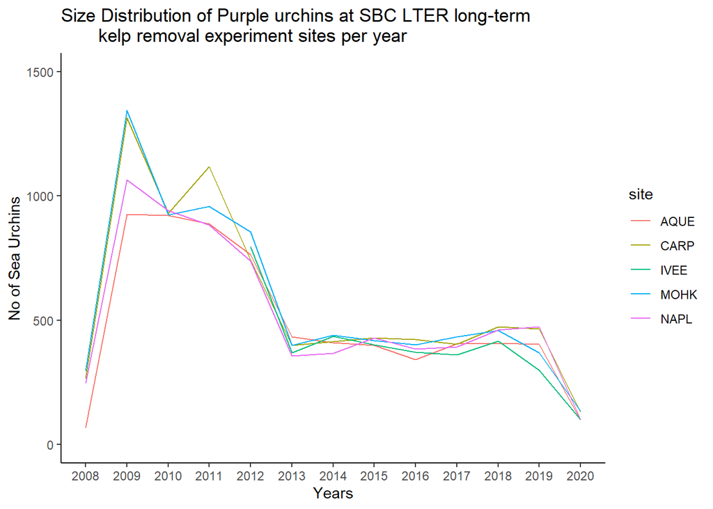

```r
ggplot(data = purple_urchins_site_year, aes(x= Year, y=Number, color=site))+
  geom_line()+
  scale_x_continuous(breaks = c(2008:2020))+
  ylim(0,1500)+
  theme_classic()+
    labs(x= "Years",
         y = "No of Sea Urchins",
         title = "Size Distribution of Purple urchins at SBC LTER long-term
       kelp removal experiment sites per year")
```

# Fig 2: Size distribution of Purple Urchins at SBC LTER. The graph above discusses the frequency of purple sea urchins found across SBC LTER long-term kelp removal experiment sites and across years

#### iv. The treatment conditions at the sites have not been segregated in this graph and therefore does not reflect the changes in the urchin population